# Missing Value Detection and Filling

Mehmet ÇAY

2022-08-23

# Missing Value Detection and Filling

(Data set information: A plastic product is produced in three parallel reactors (TK104, TK105, or TK107). For each row in the dataset, we have the same batch of raw material that was split, and fed to the 3 reactors. These values are the brittleness index for the product produced in the reactor.) There may be some missing values in our data. Look that example:

```r
data <- read.csv("C:/Users/Mehmet ÇAY/Desktop/R/Outlier_Detection_and_Missing_Data/Outlier_Detection_and_Missing_Data/brittleness-index.csv")

head(data,n=20L)
```

```
##    TK104 TK105 TK107
## 1    254   263   338
## 2    440    NA   470
## 3    501    NA   558
## 4    368   451   426
## 5    697   709   733
## 6    476   542   539
## 7    188   223   240
## 8    525   659   628
## 9    451   689   517
## 10   517   509   564
## 11   370   321   435
## 12    NA   403   306
## 13    NA   690   558
## 14    NA   460   358
## 15   396   492   429
## 16   279   369   291
## 17   450   507   520
## 18   422   370   491
## 19   406   378   489
## 20   425   549   479
```

As it seems celary, there may be some NAs. Problem is how to handle missing values? There are some methods. Let’s go further.

## Remove Missing Values

Missing values can directly be removed from data. This have some pros and cons. First big pros, there is no effort and the biggest cons is it may affect our data and model.

```r
query <- is.na(data) # gives true-false vector
head(query,n=20L)
```

```
##       TK104 TK105 TK107
##  [1,] FALSE FALSE FALSE
##  [2,] FALSE  TRUE FALSE
##  [3,] FALSE  TRUE FALSE
##  [4,] FALSE FALSE FALSE
##  [5,] FALSE FALSE FALSE
##  [6,] FALSE FALSE FALSE
##  [7,] FALSE FALSE FALSE
##  [8,] FALSE FALSE FALSE
##  [9,] FALSE FALSE FALSE
## [10,] FALSE FALSE FALSE
## [11,] FALSE FALSE FALSE
## [12,]  TRUE FALSE FALSE
## [13,]  TRUE FALSE FALSE
## [14,]  TRUE FALSE FALSE
## [15,] FALSE FALSE FALSE
## [16,] FALSE FALSE FALSE
## [17,] FALSE FALSE FALSE
## [18,] FALSE FALSE FALSE
## [19,] FALSE FALSE FALSE
## [20,] FALSE FALSE FALSE
```

```r
data_new <- na.omit(data)
head(data_new,n=20L)
```

```
##    TK104 TK105 TK107
## 1    254   263   338
## 4    368   451   426
## 5    697   709   733
## 6    476   542   539
## 7    188   223   240
## 8    525   659   628
## 9    451   689   517
## 10   517   509   564
## 11   370   321   435
## 15   396   492   429
## 16   279   369   291
## 17   450   507   520
## 18   422   370   491
## 19   406   378   489
## 20   425   549   479
## 21   544   631   591
## 22   376   291   428
## 23   335   410   424
```

## Mean Imputation

In this method, We give the mean of data to missing values.

```r
nas <- which(is.na(data$TK104))
length(nas)
```

```
## [1] 3
```

```r
nrow(data)
```

```
## [1] 23
```

```r
mean <- mean(data$TK104 , na.rm = T)
mean
```

```
## [1] 421
```

```r
data$TK104[nas] <- round(mean)

which(is.na(data$TK104))
```

```
## integer(0)
```

## Hot-Deck Imputation

What we do is basically chosing random variables from our data and putting them to missing values.

```r
index <- which(is.na(data$TK105))
length(index)
```

```
## [1] 2
```

```r
random <- sample(data$TK105[-index],  size = 2)
random
```

```
## [1] 492 223
```

```r
x <- data$TK105
x[index] <-random
which(is.na(x))
```

```
## integer(0)
```

## Using MICE Package

```r
library(VIM)
library(mice)
```

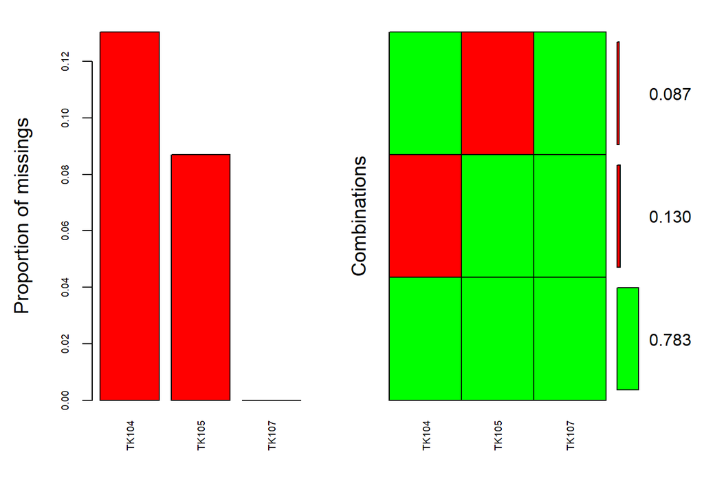

```
##
##  Variables sorted by number of missings:
##  Variable      Count
##     TK104 0.13043478
##     TK105 0.08695652
##     TK107 0.00000000
```

```r
data2 <- read.csv("C:/Users/Mehmet ÇAY/Desktop/R/Outlier_Detection_and_Missing_Data/Outlier_Detection_and_Missing_Data/brittleness-index.csv")

fig <- aggr(data2 , col = c("green" , "red") , labels = names(data2),
            numbers = TRUE , sortVars = TRUE, cex.axis = 0.6
            ) # illustrating the missing data via VIM Package
```

```r
imputed <- mice(data = data2, m = 3 , maxit = 3 ,
                method = NULL ,
                defaultMethod = c("pmm" ,"logreg" , "lda" , "polr")
                )
```

The parameters of data should be explained. Here is information from original package document: mice( data, m = 5, method = NULL, predictorMatrix, ignore = NULL, where = NULL, blocks, visitSequence = NULL, formulas, blots = NULL, post = NULL, defaultMethod = c(“pmm”, “logreg”, “polyreg”, “polr”), maxit = 5, printFlag = TRUE, seed = NA, data.init = NULL, … ) Arguments data  
A data frame or a matrix containing the incomplete data. Missing values are coded as NA.

m  
Number of multiple imputations. The default is m=5.

method  
Can be either a single string, or a vector of strings with length length(blocks), specifying the imputation method to be used for each column in data. If specified as a single string, the same method will be used for all blocks. The default imputation method (when no argument is specified) depends on the measurement level of the target column, as regulated by the defaultMethod argument. Columns that need not be imputed have the empty method ““. See details.

predictorMatrix A numeric matrix of length(blocks) rows and ncol(data) columns, containing 0/1 data specifying the set of predictors to be used for each target column. Each row corresponds to a variable block, i.e., a set of variables to be imputed. A value of 1 means that the column variable is used as a predictor for the target block (in the rows). By default, the predictorMatrix is a square matrix of ncol(data) rows and columns with all 1’s, except for the diagonal. Note: For two-level imputation models (which have “2l” in their names) other codes (e.g, 2 or -2) are also allowed.

ignore  
A logical vector of nrow(data) elements indicating which rows are ignored when creating the imputation model. The default NULL includes all rows that have an observed value of the variable to imputed. Rows with ignore set to TRUE do not influence the parameters of the imputation model, but are still imputed. We may use the ignore argument to split data into a training set (on which the imputation model is built) and a test set (that does not influence the imputation model estimates). Note: Multivariate imputation methods, like mice.impute.jomoImpute() or mice.impute.panImpute(), do not honour the ignore argument.

where  
A data frame or matrix with logicals of the same dimensions as data indicating where in the data the imputations should be created. The default, where = is.na(data), specifies that the missing data should be imputed. The where argument may be used to overimpute observed data, or to skip imputations for selected missing values.

blocks  
List of vectors with variable names per block. List elements may be named to identify blocks. Variables within a block are imputed by a multivariate imputation method (see method argument). By default each variable is placed into its own block, which is effectively fully conditional specification (FCS) by univariate models (variable-by-variable imputation). Only variables whose names appear in blocks are imputed. The relevant columns in the where matrix are set to FALSE of variables that are not block members. A variable may appear in multiple blocks. In that case, it is effectively re-imputed each time that it is visited.

visitSequence  
A vector of block names of arbitrary length, specifying the sequence of blocks that are imputed during one iteration of the Gibbs sampler. A block is a collection of variables. All variables that are members of the same block are imputed when the block is visited. A variable that is a member of multiple blocks is re-imputed within the same iteration. The default visitSequence = “roman” visits the blocks (left to right) in the order in which they appear in blocks. One may also use one of the following keywords: “arabic” (right to left), “monotone” (ordered low to high proportion of missing data) and “revmonotone” (reverse of monotone). Special case: If you specify both visitSequence = “monotone” and maxit = 1, then the procedure will edit the predictorMatrix to conform to the monotone pattern. Realize that convergence in one iteration is only guaranteed if the missing data pattern is actually monotone. The procedure does not check this.

formulas  
A named list of formula’s, or expressions that can be converted into formula’s by as.formula. List elements correspond to blocks. The block to which the list element applies is identified by its name, so list names must correspond to block names. The formulas argument is an alternative to the predictorMatrix argument that allows for more flexibility in specifying imputation models, e.g., for specifying interaction terms.

blots  
A named list of alist’s that can be used to pass down arguments to lower level imputation function. The entries of element blots[[blockname]] are passed down to the function called for block blockname.

post  
A vector of strings with length ncol(data) specifying expressions as strings. Each string is parsed and executed within the sampler() function to post-process imputed values during the iterations. The default is a vector of empty strings, indicating no post-processing. Multivariate (block) imputation methods ignore the post parameter.

defaultMethod  
A vector of length 4 containing the default imputation methods for 1) numeric data, 2) factor data with 2 levels, 3) factor data with > 2 unordered levels, and 4) factor data with > 2 ordered levels. By default, the method uses pmm, predictive mean matching (numeric data) logreg, logistic regression imputation (binary data, factor with 2 levels) polyreg, polytomous regression imputation for unordered categorical data (factor > 2 levels) polr, proportional odds model for (ordered, > 2 levels).

maxit  
A scalar giving the number of iterations. The default is 5.

printFlag  
If TRUE, mice will print history on console. Use print=FALSE for silent computation.

seed  
An integer that is used as argument by the set.seed() for offsetting the random number generator. Default is to leave the random number generator alone. Versions later than 3.13.11 reset the random generator to the state before calling mice(). This effectively isolates the mice random generator from the calling environment.

data.init  
A data frame of the same size and type as data, without missing data, used to initialize imputations before the start of the iterative process. The default NULL implies that starting imputation are created by a simple random draw from the data. Note that specification of data.init will start all m Gibbs sampling streams from the same imputation.

Now I assume you have read all information and understand what we do.

```r
summary(imputed)
```

```
## Class: mids
## Number of multiple imputations:  3
## Imputation methods:
## TK104 TK105 TK107
## "pmm" "pmm"    ""
## PredictorMatrix:
##       TK104 TK105 TK107
## TK104     0     1     1
## TK105     1     0     1
## TK107     1     1     0
```

Here is results:

```r
imputed$imp
```

```
## $TK104
##      1   2   3
## 12 188 254 279
## 13 476 517 476
## 14 335 335 254
##
## $TK105
##     1   2   3
## 2 689 542 321
## 3 509 631 690
##
## $TK107
## [1] 1 2 3
## <0 rows> (or 0-length row.names)
```

After we decide which iteration is more suitable, we should fill the data.

```r
imputedData <- complete(imputed , 3)
```

## Using Amelia Package

(Data set information: Grades from a Chemical Engineering course at McMaster University.)

```r
library(Amelia)
data3 <- read.csv("C:/Users/Mehmet ÇAY/Desktop/R/Outlier_Detection_and_Missing_Data/Outlier_Detection_and_Missing_Data/class-grades.csv")

result <- amelia(data3,mu=3)
```

```
## -- Imputation 1 --
##
##   1  2  3
##
## -- Imputation 2 --
##
##   1  2  3
##
## -- Imputation 3 --
##
##   1  2  3
##
## -- Imputation 4 --
##
##  No missing data in bootstrapped sample:  EM chain unnecessary
## -- Imputation 5 --
##
##   1  2  3
```

```r
# m: imputation number
# noms: nominal variables

names(result)
```

```
##  [1] "imputations" "m"           "missMatrix"  "overvalues"  "theta"
##  [6] "mu"          "covMatrices" "code"        "message"     "iterHist"
## [11] "arguments"   "orig.vars"
```

```r
head(result$imputations,n=10L)
```

```
## $imp1
##    Prefix Assignment Tutorial Midterm  TakeHome     Final
## 1       5      57.14    34.09   64.38  51.48000  52.50000
## 2       8      95.05   105.49   67.50  99.07000  68.33000
## 3       8      83.70    83.17   30.00  63.15000  48.89000
## 4       7      81.22    96.06   49.38 105.93000  80.56000
## 5       8      91.32    93.64   95.00 107.41000  73.89000
## 6       7      95.00    92.58   93.12  97.78000  68.06000
## 7       8      95.05   102.99   56.25  99.07000  50.00000
## 8       7      72.85    86.85   60.00  72.04935  56.11000
## 9       8      84.26    93.10   47.50  18.52000  50.83000
## 10      7      90.10    97.55   51.25  88.89000  63.61000
## 11      7      80.44    90.20   75.00  91.48000  39.72000
## 12      6      86.26    80.60   74.38  87.59000  77.50000
## 13      8      97.16   103.71   72.50  93.52000  63.33000
```

[output cut: 494 more lines]

Differently from Mice, Amelia automatically fill the data.

## Using Hmisc Package

```r
library(Hmisc)
data4 <- read.csv("C:/Users/Mehmet ÇAY/Desktop/R/Outlier_Detection_and_Missing_Data/Outlier_Detection_and_Missing_Data/class-grades.csv")

result <- impute(data4$Final , fun = "random")
result <- impute(data4$Final , fun = mean)
result <- impute(data4$Final  , fun = median)
as.numeric(result)
```

```
##  [1]  52.50  68.33  48.89  80.56  73.89  68.06  50.00  56.11  50.83  63.61
## [11]  39.72  77.50  63.33  92.22  35.83  90.00  53.33  49.17  62.50  91.11
## [21]  66.25  66.11  34.44  72.22  56.39  92.78  89.17  88.89  85.56  45.56
## [31]  63.33  55.00  43.33 107.78  64.72  50.83  47.78  51.67  66.25  85.00
## [41]  68.33  90.83  83.33  82.22  55.83  45.56  65.28  72.22 102.22  48.89
## [51]  65.56  57.78  95.00  99.17  36.11  49.44  28.06  47.78  78.89  46.67
## [61]  66.25  60.56  58.33 101.11  88.89  94.44  67.22  63.89 108.89  66.67
## [71]  90.00  87.22  83.06  75.56  50.00 102.78  80.00  65.28  78.89  61.39
## [81]  90.00  55.00  83.89  62.78  42.78  61.11  39.44  73.89  75.83  58.61
## [91]  71.11  66.39  78.33  85.00  61.94  39.72  87.78  85.56  77.22
```

impute function actually does what we did previous methods. It is more easy to use.

```r
result2 <- aregImpute(~ Midterm + TakeHome + Final ,
                     data  = data4 , n.impute = 3)
```

```
## Iteration 1
Iteration 2
Iteration 3
Iteration 4
Iteration 5
Iteration 6
```

```r
names(result2)
```

```
##  [1] "call"       "formula"    "match"      "fweighted"  "pmmtype"
##  [6] "n"          "p"          "na"         "nna"        "type"
## [11] "tlinear"    "nk"         "cat.levels" "df"         "n.impute"
## [16] "imputed"    "x"          "rsq"        "resampacc"
```

```r
result2
```

```
##
## Multiple Imputation using Bootstrap and PMM
##
## aregImpute(formula = ~Midterm + TakeHome + Final, data = data4,
##     n.impute = 3)
##
## n: 99    p: 3    Imputations: 3      nk: 3
##
## Number of NAs:
##  Midterm TakeHome    Final
##        0        1        3
##
##          type d.f.
## Midterm     s    2
## TakeHome    s    2
## Final       s    1
##
## Transformation of Target Variables Forced to be Linear
##
## R-squares for Predicting Non-Missing Values for Each Variable
## Using Last Imputations of Predictors
## TakeHome    Final
##    0.536    0.616
```

aregImpute create a regression and use it to fill data.

## MissForest

```r
library(missForest)
data5 <- read.csv("C:/Users/Mehmet ÇAY/Desktop/R/Outlier_Detection_and_Missing_Data/Outlier_Detection_and_Missing_Data/class-grades.csv")

library(rstatix)
new_data <- sample_n_by(data5 , size = 50) #taking 50 sample
new_data <- as.data.frame(new_data)

result3 <- missForest(new_data , maxiter = 4)

result3
```

```
## $ximp
##    Prefix Assignment Tutorial Midterm TakeHome     Final
## 1       7      91.28   108.71   96.25  99.8100  88.89000
## 2       8      85.01    98.47   91.25  83.3300  72.22000
## 3       7      95.14    82.67  110.00  89.8100  90.83000
## 4       8      84.26    93.10   47.50  18.5200  50.83000
## 5       7      98.58    91.03  101.25 104.2600 107.78000
## 6       8      92.02   100.58   54.37  63.8900  63.89000
## 7       7      84.26    91.31   63.12  83.3300  75.56000
## 8       6      57.14    34.09   66.88  51.4800  55.83000
## 9       8      97.16   103.71   83.75  95.9300  78.89000
## 10      8      83.70    83.17   60.62  63.1500  57.78000
## 11      6      90.74    89.64   61.25  90.0000  61.31500
## 12      8      96.73   103.71   45.00  93.5200  61.94000
## 13      8      87.93   108.97   28.75  87.9600  47.78000
```

[output cut: 44 more lines]

```r
result3$ximp
```

```
##    Prefix Assignment Tutorial Midterm TakeHome     Final
## 1       7      91.28   108.71   96.25  99.8100  88.89000
## 2       8      85.01    98.47   91.25  83.3300  72.22000
## 3       7      95.14    82.67  110.00  89.8100  90.83000
## 4       8      84.26    93.10   47.50  18.5200  50.83000
## 5       7      98.58    91.03  101.25 104.2600 107.78000
## 6       8      92.02   100.58   54.37  63.8900  63.89000
## 7       7      84.26    91.31   63.12  83.3300  75.56000
## 8       6      57.14    34.09   66.88  51.4800  55.83000
## 9       8      97.16   103.71   83.75  95.9300  78.89000
## 10      8      83.70    83.17   60.62  63.1500  57.78000
## 11      6      90.74    89.64   61.25  90.0000  61.31500
## 12      8      96.73   103.71   45.00  93.5200  61.94000
## 13      8      87.93   108.97   28.75  87.9600  47.78000
## 14      8      97.16   103.71   72.50  93.5200  63.33000
```

[output cut: 36 more lines]

```r
result3$OOBerror
```

```
##    NRMSE
## 0.294557
```